# Apriori

1. Large clusters of co-occuring items should probably be placed in their own category / theme
2. Item pairs that commonly co-occur should be placed close together within broader categories on the website. This is especially important where one item in a pair is very popular, and the other item is very high margin.
3. Long lists of rules (including ones with low support and confidence) can be used to put recommendations at the bottom of product pages and on product cart pages. The only thing that matters for these rules is that the lift is greater than one. (And that we pick those rules that are applicable for each product with the high lift where the product recommended has a high margin.) In the event that doing the above (3) drives significant uplift in profit, it would strengthen the case to invest in a recommendation system, that uses a similar algorithm in an operational context to power automatic recommendation engine on your website.

```r
#All1= read.csv('Ingres_All.csv', header =F, strip.white=TRUE, sep=',')
#All2 = read.csv("tagsAll-Name.csv",header =F, strip.white=TRUE, sep=',')
#轉型join
#All1[,2] = as.character(All1[,2])
#All2[,2] = as.character(All2[,2])
#All= inner_join(All1, All2, by = c('V2'='V2'))
#配對回主類別
#All[,3] = sub("([[:alpha:]]{1}[[:digit:]]+)", "", All[,3])
#filter調味料和其他
#ALL = All %>% filter(V1.y!="K")%>% filter(V1.y!="L")
#write.table(ALL,'ALL_forApriori.txt', sep=',', quote=F, row.names=F, col.names=F)
ALL = read.csv("ALL_forApriori.txt",header =F, strip.white=TRUE, sep=',')
#生成lists
bll = tapply(ALL[,2], ALL[,1], paste)
#filter null lists
Bll = Filter(Negate(is.null), bll)
#filter dup lists
ingreList = lapply(Bll, unique)
head(bll)
```

```
## $I00001
## [1] "雞腿排" "米"     "香菇"
##
## $I00002
## [1] "雞蛋" "起司"
##
## $I00003
## [1] "雞蛋"
##
## $I00004
## [1] "糯米"   "雞胸肉"
##
## $I00005
## [1] "鱈魚"
##
## $I00006
## [1] "高麗菜"
```

```r
#寫成transaction file
trans = as(ingreList, "transactions")
trans
```

```
## transactions in sparse format with
##  55030 transactions (rows) and
##  1330 items (columns)
```

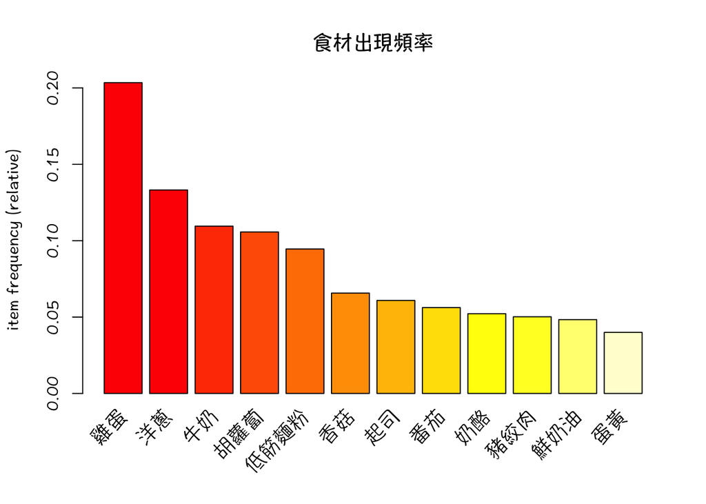

```r
par(family="Hannotate TC")
itemFrequencyPlot(trans, support = 0.01, cex.names=1.2,topN=12, main="食材出現頻率",col=heat.colors(12))
```

```r
#Apriori rules - STRONG rules- visulization用
rules = apriori(trans, parameter = list(supp = 0.01, conf =0.5, target= "rules"))
```

```
##
## Parameter specification:
##  confidence minval smax arem  aval originalSupport support minlen maxlen
##         0.5    0.1    1 none FALSE            TRUE    0.01      1     10
##  target   ext
##   rules FALSE
##
## Algorithmic control:
##  filter tree heap memopt load sort verbose
##     0.1 TRUE TRUE  FALSE TRUE    2    TRUE
##
## apriori - find association rules with the apriori algorithm
## version 4.21 (2004.05.09)        (c) 1996-2004   Christian Borgelt
## set item appearances ...[0 item(s)] done [0.00s].
## set transactions ...[1330 item(s), 55030 transaction(s)] done [0.02s].
## sorting and recoding items ... [87 item(s)] done [0.00s].
## creating transaction tree ... done [0.03s].
## checking subsets of size 1 2 3 4 done [0.00s].
## writing ... [17 rule(s)] done [0.00s].
## creating S4 object  ... done [0.01s].
```

```r
summary(rules)
```

```
## set of 17 rules
##
## rule length distribution (lhs + rhs):sizes
##  2  3
##  5 12
##
##    Min. 1st Qu.  Median    Mean 3rd Qu.    Max.
##   2.000   2.000   3.000   2.706   3.000   3.000
##
## summary of quality measures:
##     support          confidence          lift
##  Min.   :0.01010   Min.   :0.5268   Min.   : 2.708
##  1st Qu.:0.01127   1st Qu.:0.5510   1st Qu.: 3.231
##  Median :0.01179   Median :0.5847   Median : 5.228
##  Mean   :0.01781   Mean   :0.6074   Mean   : 6.436
##  3rd Qu.:0.02090   3rd Qu.:0.6281   3rd Qu.: 6.569
##  Max.   :0.05530   Max.   :0.8451   Max.   :18.746
##
## mining info:
##   data ntransactions support confidence
##  trans         55030    0.01        0.5
```

```r
inspect(rules)
```

```
##    lhs           rhs           support confidence      lift
## 1  {洋菇}     => {洋蔥}     0.01059422  0.5489642  4.121351
## 2  {蛋黃}     => {低筋麵粉} 0.02138833  0.5350000  5.657389
## 3  {奶酪}     => {低筋麵粉} 0.02822097  0.5405499  5.716077
## 4  {奶酪}     => {雞蛋}     0.02876613  0.5509920  2.708207
## 5  {低筋麵粉} => {雞蛋}     0.05529711  0.5847425  2.874096
## 6  {蛋白,
##     蛋黃}     => {低筋麵粉} 0.01179357  0.8450521  8.936052
## 7  {低筋麵粉,
##     蛋白}     => {蛋黃}     0.01179357  0.7494226 18.745785
## 8  {低筋麵粉,
##     蛋黃}     => {蛋白}     0.01179357  0.5514019 17.339226
## 9  {胡蘿蔔,
##     馬鈴薯}   => {洋蔥}     0.01010358  0.6191537  4.648298
## 10 {洋蔥,
##     馬鈴薯}   => {胡蘿蔔}   0.01010358  0.5526839  5.227603
## 11 {低筋麵粉,
##     蛋黃}     => {牛奶}     0.01126658  0.5267630  4.808853
## 12 {牛奶,
##     蛋黃}     => {低筋麵粉} 0.01126658  0.6212425  6.569365
## 13 {奶酪,
##     牛奶}     => {低筋麵粉} 0.01073960  0.5628571  5.951966
## 14 {低筋麵粉,
##     奶酪}     => {雞蛋}     0.01855352  0.6574372  3.231401
## 15 {奶酪,
##     雞蛋}     => {低筋麵粉} 0.01855352  0.6449779  6.820356
## 16 {奶酪,
##     牛奶}     => {雞蛋}     0.01155733  0.6057143  2.977176
## 17 {低筋麵粉,
##     牛奶}     => {雞蛋}     0.02089769  0.6280721  3.087067
```

```r
#prun redundant rules
rules.sorted = sort(rules, by="lift")
subset.matrix = is.subset(rules.sorted, rules.sorted)
subset.matrix[lower.tri(subset.matrix, diag=T)] = NA
redundant = colSums(subset.matrix, na.rm=T) >= 1
rules.pruned = rules.sorted[!redundant]
inspect(rules.pruned)
```

```
##    lhs           rhs           support confidence      lift
## 1  {低筋麵粉,
##     蛋白}     => {蛋黃}     0.01179357  0.7494226 18.745785
## 2  {奶酪,
##     雞蛋}     => {低筋麵粉} 0.01855352  0.6449779  6.820356
## 3  {牛奶,
##     蛋黃}     => {低筋麵粉} 0.01126658  0.6212425  6.569365
## 4  {奶酪,
##     牛奶}     => {低筋麵粉} 0.01073960  0.5628571  5.951966
## 5  {奶酪}     => {低筋麵粉} 0.02822097  0.5405499  5.716077
## 6  {蛋黃}     => {低筋麵粉} 0.02138833  0.5350000  5.657389
## 7  {洋蔥,
##     馬鈴薯}   => {胡蘿蔔}   0.01010358  0.5526839  5.227603
## 8  {洋菇}     => {洋蔥}     0.01059422  0.5489642  4.121351
## 9  {低筋麵粉,
##     牛奶}     => {雞蛋}     0.02089769  0.6280721  3.087067
## 10 {奶酪,
##     牛奶}     => {雞蛋}     0.01155733  0.6057143  2.977176
## 11 {低筋麵粉} => {雞蛋}     0.05529711  0.5847425  2.874096
## 12 {奶酪}     => {雞蛋}     0.02876613  0.5509920  2.708207
```

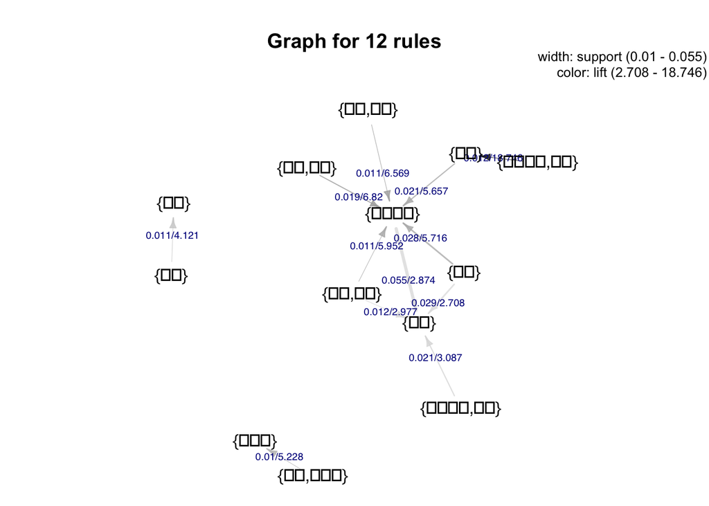

```r
plot(sort(rules.pruned, by="lift"), method="graph",control=list(type="itemsets", measureLabels=T))
```

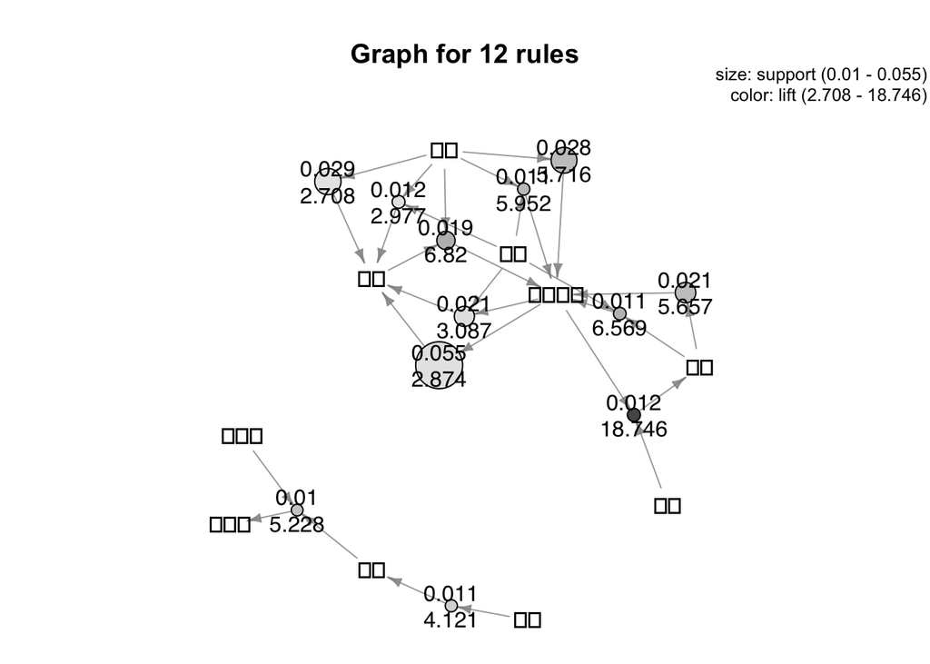

```r
plot(sort(rules.pruned, by="lift"), method="graph",control=list(type="items", measureLabels=T))
```

[figure not shown]

```r
plot(rules.pruned, method="grouped")
```

```r
#Apriori rules - STRONG rules- visulization用-2-降低minsup門檻 mine interesting rules
rules = apriori(trans, parameter = list(supp = 0.001, conf =0.5, target= "rules"))
```

```
##
## Parameter specification:
##  confidence minval smax arem  aval originalSupport support minlen maxlen
##         0.5    0.1    1 none FALSE            TRUE   0.001      1     10
##  target   ext
##   rules FALSE
##
## Algorithmic control:
##  filter tree heap memopt load sort verbose
##     0.1 TRUE TRUE  FALSE TRUE    2    TRUE
##
## apriori - find association rules with the apriori algorithm
## version 4.21 (2004.05.09)        (c) 1996-2004   Christian Borgelt
## set item appearances ...[0 item(s)] done [0.00s].
## set transactions ...[1330 item(s), 55030 transaction(s)] done [0.02s].
## sorting and recoding items ... [369 item(s)] done [0.00s].
## creating transaction tree ... done [0.03s].
## checking subsets of size 1 2 3 4 5 done [0.02s].
## writing ... [459 rule(s)] done [0.00s].
## creating S4 object  ... done [0.01s].
```

```r
summary(rules) #459
```

```
## set of 459 rules
##
## rule length distribution (lhs + rhs):sizes
##   2   3   4   5
##  37 258 138  26
##
##    Min. 1st Qu.  Median    Mean 3rd Qu.    Max.
##   2.000   3.000   3.000   3.333   4.000   5.000
##
## summary of quality measures:
##     support           confidence          lift
##  Min.   :0.001018   Min.   :0.5000   Min.   :  2.458
##  1st Qu.:0.001218   1st Qu.:0.5680   1st Qu.:  4.402
##  Median :0.001635   Median :0.6352   Median :  5.906
##  Mean   :0.002768   Mean   :0.6567   Mean   : 11.656
##  3rd Qu.:0.002662   3rd Qu.:0.7198   3rd Qu.:  8.830
##  Max.   :0.055297   Max.   :1.0000   Max.   :170.477
##
## mining info:
##   data ntransactions support confidence
##  trans         55030   0.001        0.5
```

```r
inspect(rules)
```

```
##     lhs           rhs            support confidence       lift
## 1   {餛飩皮}   => {豬絞肉}   0.001090314  0.5128205  10.217420
## 2   {蔘鬚}     => {紅棗}     0.001199346  0.6534653  52.727563
## 3   {蔘鬚}     => {枸杞}     0.001199346  0.6534653  35.014798
## 4   {牛肋排}   => {胡蘿蔔}   0.001453752  0.5633803   5.328776
## 5   {牛肋排}   => {洋蔥}     0.001817191  0.7042254   5.286974
## 6   {川芎}     => {當歸藥包} 0.001381065  0.8085106 165.399035
## 7   {川芎}     => {枸杞}     0.001308377  0.7659574  41.042491
## 8   {牛腩}     => {胡蘿蔔}   0.001671815  0.6133333   5.801260
## 9   {檸檬葉}   => {魚露}     0.001562784  0.6666667  40.627538
## 10  {丁香}     => {八角}     0.001871706  0.6023392  38.813495
## 11  {壽司}     => {海苔}     0.001671815  0.6618705  29.830249
## 12  {水餃皮}   => {豬絞肉}   0.002253316  0.5061224  10.083968
## 13  {黃耆}     => {當歸藥包} 0.001817191  0.5586592 114.286308
## 14  {黃耆}     => {紅棗}     0.002017082  0.6201117  50.036288
## 15  {黃耆}     => {枸杞}     0.002544067  0.7821229  41.908689
## 16  {消化餅乾} => {奶油起司} 0.002707614  0.6535088  59.639449
## 17  {消化餅乾} => {雞蛋}     0.002235144  0.5394737   2.651593
## 18  {披薩}     => {起司}     0.003143740  0.8737374  14.348483
## 19  {牛絞肉}   => {洋蔥}     0.002925677  0.6625514   4.974107
## 20  {奶水}     => {低筋麵粉} 0.003398146  0.5862069   6.198879
## 21  {奶水}     => {雞蛋}     0.003398146  0.5862069   2.881294
## 22  {當歸藥包} => {枸杞}     0.003834272  0.7843866  42.029986
## 23  {鬆餅粉}   => {牛奶}     0.004433945  0.6455026   5.892835
## 24  {鬆餅粉}   => {雞蛋}     0.005578775  0.8121693   3.991933
## 25  {木耳}     => {胡蘿蔔}   0.005288025  0.5480226   5.183514
## 26  {紅棗}     => {枸杞}     0.006360167  0.5131965  27.498736
## 27  {奶粉}     => {雞蛋}     0.008322733  0.5841837   2.871349
## 28  {西洋芹菜} => {胡蘿蔔}   0.006251136  0.5058824   4.784927
## 29  {西洋芹菜} => {洋蔥}     0.007323278  0.5926471   4.449300
## 30  {麵包粉}   => {雞蛋}     0.007741232  0.5958042   2.928466
## 31  {杏仁}     => {低筋麵粉} 0.008613484  0.5042553   5.332277
## 32  {蝦米}     => {香菇}     0.008740687  0.5344444   8.135679
## 33  {洋菇}     => {洋蔥}     0.010594221  0.5489642   4.121351
## 34  {蛋黃}     => {低筋麵粉} 0.021388334  0.5350000   5.657389
## 35  {奶酪}     => {低筋麵粉} 0.028220970  0.5405499   5.716077
## 36  {奶酪}     => {雞蛋}     0.028766128  0.5509920   2.708207
## 37  {低筋麵粉} => {雞蛋}     0.055297111  0.5847425   2.874096
## 38  {牛肋排,
##      胡蘿蔔}   => {洋蔥}     0.001217518  0.8375000   6.287534
```

[output cut: 1017 more lines]

```
##      牛奶,
##      蛋黃,
##      雞蛋}     => {低筋麵粉} 0.001417409  0.8041237   8.503253
## 457 {低筋麵粉,
##      奶酪,
##      牛奶,
##      鮮奶油}   => {雞蛋}     0.001490096  0.7256637   3.566745
## 458 {低筋麵粉,
##      奶酪,
##      雞蛋,
##      鮮奶油}   => {牛奶}     0.001490096  0.5578231   5.092403
## 459 {奶酪,
##      牛奶,
##      雞蛋,
##      鮮奶油}   => {低筋麵粉} 0.001490096  0.6833333   7.225948
```

```r
#prun redundant rules
rules.sorted = sort(rules, by="lift")
subset.matrix = is.subset(rules.sorted, rules.sorted)
subset.matrix[lower.tri(subset.matrix, diag=T)] = NA
redundant = colSums(subset.matrix, na.rm=T) >= 1
rules.pruned = rules.sorted[!redundant]
inspect(rules.pruned) #309
```

```
##     lhs           rhs            support confidence       lift
## 1   {川芎,
##      枸杞}     => {當歸藥包} 0.001090314  0.8333333 170.477076
## 2   {枸杞,
##      當歸藥包,
##      紅棗}     => {黃耆}     0.001072142  0.5514019 169.517569
## 3   {川芎}     => {當歸藥包} 0.001381065  0.8085106 165.399035
## 4   {當歸藥包,
##      紅棗}     => {黃耆}     0.001163002  0.5000000 153.715084
## 5   {枸杞,
##      黃耆}     => {當歸藥包} 0.001617300  0.6357143 130.049655
## 6   {黃耆}     => {當歸藥包} 0.001817191  0.5586592 114.286308
## 7   {消化餅乾,
##      雞蛋}     => {奶油起司} 0.001671815  0.7479675  68.259785
## 8   {奶酪,
##      消化餅乾} => {奶油起司} 0.001308377  0.7200000  65.707463
## 9   {消化餅乾,
##      鮮奶油}   => {奶油起司} 0.001253862  0.6571429  59.971097
## 10  {消化餅乾} => {奶油起司} 0.002707614  0.6535088  59.639449
## 11  {枸杞,
##      黃耆}     => {紅棗}     0.001689987  0.6642857  53.600649
## 12  {蔘鬚}     => {紅棗}     0.001199346  0.6534653  52.727563
## 13  {黃耆}     => {紅棗}     0.002017082  0.6201117  50.036288
## 14  {當歸藥包,
##      紅棗}     => {枸杞}     0.001944394  0.8359375  44.792250
## 15  {當歸藥包} => {枸杞}     0.003834272  0.7843866  42.029986
## 16  {黃耆}     => {枸杞}     0.002544067  0.7821229  41.908689
## 17  {川芎}     => {枸杞}     0.001308377  0.7659574  41.042491
## 18  {土司,
##      草莓}     => {煉乳}     0.001072142  0.5728155  40.884616
## 19  {檸檬葉}   => {魚露}     0.001562784  0.6666667  40.627538
## 20  {丁香}     => {八角}     0.001871706  0.6023392  38.813495
## 21  {糯米,
##      香菇}     => {蝦米}     0.001944394  0.6079545  37.173043
## 22  {蔘鬚}     => {枸杞}     0.001199346  0.6534653  35.014798
## 23  {壽司}     => {海苔}     0.001671815  0.6618705  29.830249
## 24  {蝦,
##      透抽}     => {蛤}       0.001453752  0.5194805  28.558455
## 25  {紅棗}     => {枸杞}     0.006360167  0.5131965  27.498736
## 26  {低筋麵粉,
```

[output cut: 586 more lines]

```
##      牛奶}     => {雞蛋}     0.002180629  0.5607477   2.756158
## 302 {奶酪,
##      杏仁}     => {雞蛋}     0.002562239  0.5595238   2.750142
## 303 {奶油起司,
##      奶酪}     => {雞蛋}     0.001962566  0.5567010   2.736268
## 304 {奶酪,
##      鮮奶油}   => {雞蛋}     0.004088679  0.5555556   2.730638
## 305 {蝦仁,
##      飯}       => {雞蛋}     0.001235690  0.5528455   2.717318
## 306 {奶酪}     => {雞蛋}     0.028766128  0.5509920   2.708207
## 307 {牛奶,
##      玉米粒}   => {雞蛋}     0.001053971  0.5420561   2.664286
## 308 {消化餅乾} => {雞蛋}     0.002235144  0.5394737   2.651593
## 309 {玉米粉,
##      鮮奶油}   => {雞蛋}     0.002107941  0.5201794   2.556759
```

[figure not shown]

```r
plot(sort(rules.pruned, by="lift"), method="graph",control=list(type="itemsets", measureLabels=T))
```

[figure not shown]

```r
plot(sort(rules.pruned, by="lift"), method="graph",control=list(type="items", measureLabels=T))
```

[figure not shown]

```r
plot(rules.pruned, method="grouped")
```

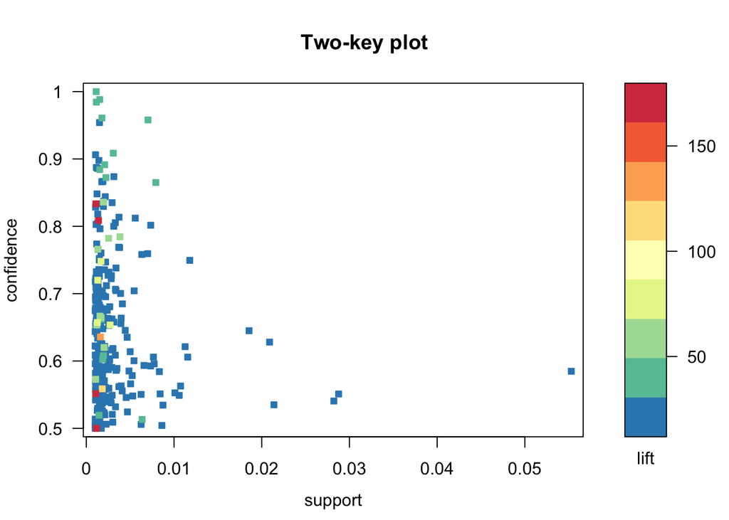

```r
plot(rules.pruned, control=list(col=brewer.pal(9,"Spectral"), main = "Two-key plot", cex=0.5, jitter =2))
```

```
## Itemsets in Antecedent (LHS)
##   [1] "{川芎}"                      "{川芎,枸杞}"
##   [3] "{枸杞,黃耆}"                 "{黃耆}"
##   [5] "{蔘鬚}"                      "{當歸藥包}"
##   [7] "{紅棗}"                      "{牛奶,蛋液}"
##   [9] "{奶粉,牛奶}"                 "{蛋液,雞蛋}"
##  [11] "{奶粉,蛋液}"                 "{奶酪,牛奶,蛋液}"
##  [13] "{奶粉,雞蛋}"                 "{奶酪,蛋白}"
##  [15] "{奶酪,牛奶,玉米粉}"          "{玉米粉,蛋白}"
##  [17] "{草莓,蛋白}"                 "{蛋白,鮮奶油}"
##  [19] "{牛奶,蛋白}"                 "{牛奶,蛋白,鮮奶油}"
##  [21] "{牛奶,玉米粉,蛋白}"          "{奶油起司,蛋白}"
##  [23] "{低筋麵粉,奶油起司,蛋白}"    "{低筋麵粉,牛奶,玉米粉,蛋白}"
##  [25] "{奶油起司,牛奶,蛋白}"        "{低筋麵粉,牛奶,蛋白}"
##  [27] "{低筋麵粉,蛋白,鮮奶油}"      "{低筋麵粉,玉米粉,蛋白}"
```

[output cut: 117 more lines]

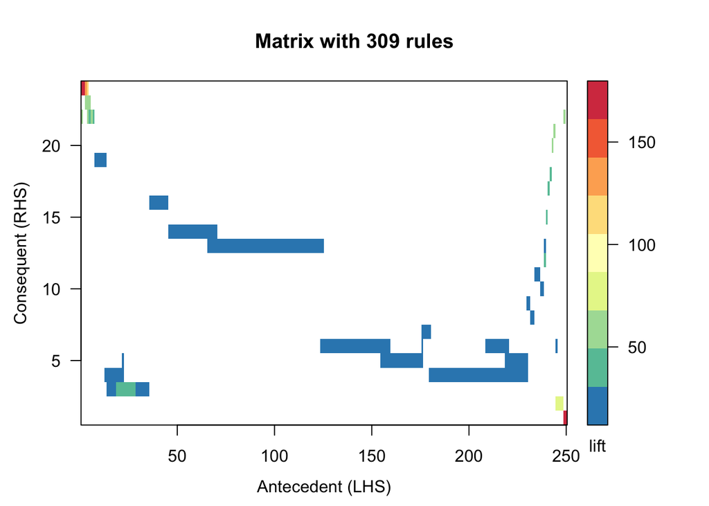

```r
## 2D matrix with shading
plot(rules.pruned, method="matrix", measure="lift", control=list(reorder=TRUE, col=brewer.pal(9,"Spectral")))
```